# Data Analysis Project

## Data Exploration

I’ve moved this section to the end

The most interesting and intuitive graphs I found were in the process of assessing leverage values of the small linear model and the faceting of the regression of log salary on log career runs and dummy variables of years. To me, it looks like many of the points in the first two facets(the groups with years less than 6) are closely following the least squares regression line of the last facet.

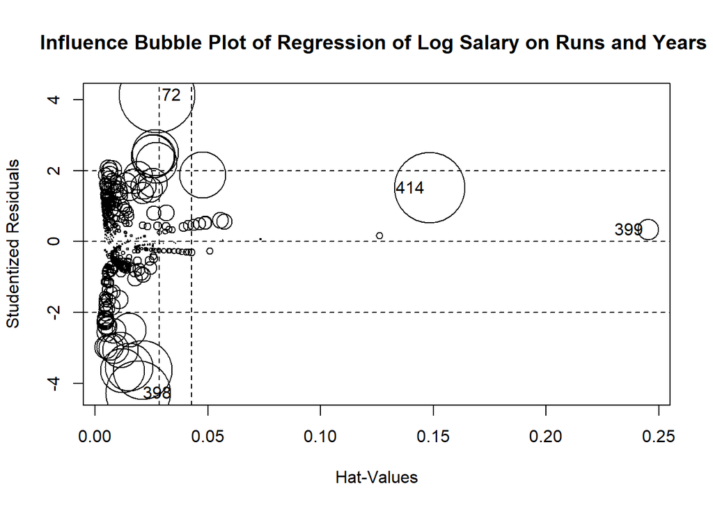

|  | StudRes | Hat | CookD |
| --- | --- | --- | --- |
| 72 | 4.1242435 | 0.02738064 | 0.076842127 |
| 398 | -4.2731130 | 0.01891365 | 0.056326027 |
| 399 | 0.3341188 | 0.24528186 | 0.006059851 |
| 414 | 1.5133196 | 0.14829839 | 0.066253833 |

```r
influencePlot(lm_small, main = "Influence Bubble Plot of Regression of Log Salary on Runs and Years ")
```

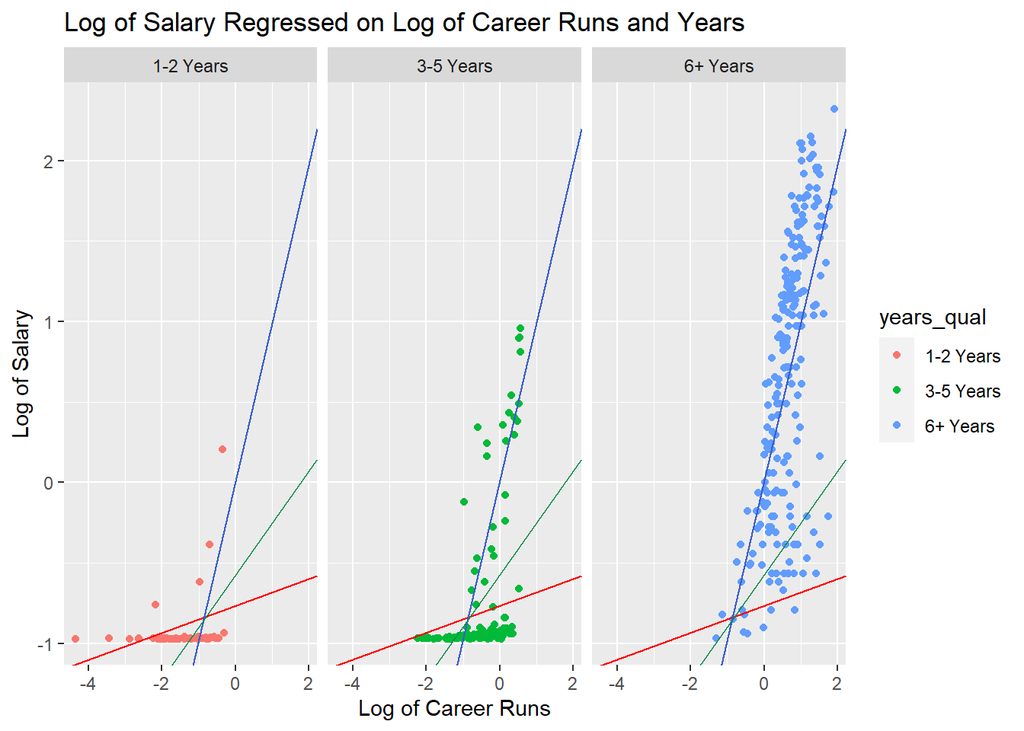

```r
ggplot(data = small_graph_df, aes(x =  log_CR, y = log_salary)) + geom_point(aes(color = years_qual)) + xlab("Log of Career Runs") +ylab("Log of Salary") + facet_grid(.~years_qual) + geom_abline(slope = 0.08383, intercept = -0.7654, color = "red") + geom_abline(intercept = -0.7654 + 0.77467, slope = 0.08383 + 0.90160, color = "royalblue3") + geom_abline(intercept = -0.76549 + 0.19170, slope = 0.08383 + 0.23912, color = "springgreen4") + ggtitle("Log of Salary Regressed on Log of Career Runs and Years")
```